# 简述

本文的目标是分析人口数据，并推测未来人口和供养率。

# 基本原理

人在出生后，就会不停死亡。每一年的人，能活到第二年的概率，有一个模型，叫[生命表](https://zh.wikipedia.org/wiki/%E7%94%9F%E5%91%BD%E8%A1%A8)。根据这个表，以及每年出生人口，你可以大致算出后续某年，几岁的人还有多少活着。

这个模型有几个问题。首先，生命表并不反应历史重大事件。例如，因为战争，饥荒，导致人口大量死亡。这个在生命表里是反应不出来的。其次，出生人口数据不是无限前推的。例如，你要算出今年100虽的人口有多少（假设生命表准确，上推的极限是105岁），就需要1924年的出生人口作为原始数据。这个原始数据我反正没有。所以，我们这个计算只能以其他方式进行拟合（或者叫凑合）。

这个凑合的最重要数据，就是每年总人口。每年出生数据是原始数据。用出生人口推算出来的每个年龄的人口数据，叫直接推断数据。用总人口减去直接推断数据，就得到剩余，这部分是间接数据。理论上说，如果有年龄分布数据的话，可以把剩余分布到各个年龄段。但是很可惜，这个修正对于刚开始的数据（在我这里是1949年前后）比较重要。可是我没有1949年的人口分布模型。到2024年的时候，1949年出生的人已经75了，分布模型也不重要了。所以我用了一个很土的办法——把剩余均摊到后面的年龄上去。

另一个参考数据，则是七普（或者你也可以用六普的数据附加校验）数据。七普是2020年，所以这张表算出来的2020年人口模型，应当符合2020年人口的年龄分布。

```python
import pandas as pd
import numpy as np
from scipy import interpolate
import matplotlib.pyplot as plt
from matplotlib import cm
%matplotlib ipympl
```

# 原始人口数据

人口数据最权威的源头，来自国家统计局。[这个页面](https://data.stats.gov.cn/easyquery.htm?cn=C01)下方找“人口-总人口”，可以找到1949年之后的历年总人口数据。可惜的是，这张表并没有历年出生人口数据。我在[这里](https://zhuanlan.zhihu.com/p/634146715)找到了出生人口数据和总人口数据。经过核对，两者在总人口上一致。由此，我们得到了人口的基本原始数据。同时，我借鉴[这里](https://mlcldh.github.io/society/%E4%B8%AD%E5%9B%BD%E5%8E%86%E5%B9%B4%E5%87%BA%E7%94%9F%E4%BA%BA%E5%8F%A3.html)补充了49年和之前的一些出生数据。

注意，在统计局“人口-人口抽样调查样本数据”里面，可以找到按年龄分人口数据。但是这个数据经过我查验之后，和生命表模型有重大偏差。实话说我也不是很理解，为什么0-4岁人口占总人口的比例，和前5年新生人口统计出来的比例，两者偏差很大。我只能推测里面有一些我不知道的故事。但结论是，这个数据对我们的进一步分析用处不大。

```python
population = pd.read_csv('population.csv', index_col='year')
population
```

| year | birth | total |
| --- | --- | --- |
| 1946 | 1009 | NaN |
| 1947 | 1122 | NaN |
| 1948 | 1139 | NaN |
| 1949 | 1275 | 54167.0 |
| 1950 | 2023 | 55196.0 |
| ... | ... | ... |
| 2019 | 1465 | 141008.0 |
| 2020 | 1202 | 141212.0 |
| 2021 | 1062 | 141260.0 |
| 2022 | 956 | 141175.0 |
| 2023 | 902 | 141236.0 |

78 rows × 2 columns

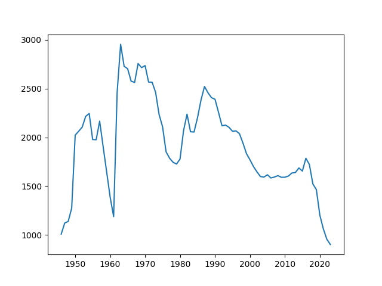

```python
plt.close()
plt.plot(population['birth'])
plt.show()
```

# 生命表数据

你可以随便下一个差不多的生命表，我用的是[这张](https://www.cbirc.gov.cn/cn/view/pages/ItemDetail_gdsj.html?docId=19861&docType=2)。其中：

1. CL1（2010－2013）：非养老类业务一表（男）；
2. CL2（2010－2013）：非养老类业务一表（女）；
3. CL3（2010－2013）：非养老类业务二表（男）；
4. CL4（2010－2013）：非养老类业务二表（女）；
5. CL5（2010－2013）：养老类业务表（男）；
6. CL6（2010－2013）：养老类业务表（女）。

```python
life = pd.read_csv('life.csv', index_col='age')
life
```

| age | CL1 | CL2 | CL3 | CL4 | CL5 | CL6 |
| --- | --- | --- | --- | --- | --- | --- |
| 0 | 0.000867 | 0.000620 | 0.000620 | 0.000455 | 0.000566 | 0.000453 |
| 1 | 0.000615 | 0.000456 | 0.000465 | 0.000324 | 0.000386 | 0.000289 |
| 2 | 0.000445 | 0.000337 | 0.000353 | 0.000236 | 0.000268 | 0.000184 |
| 3 | 0.000339 | 0.000256 | 0.000278 | 0.000180 | 0.000196 | 0.000124 |
| 4 | 0.000280 | 0.000203 | 0.000229 | 0.000149 | 0.000158 | 0.000095 |
| ... | ... | ... | ... | ... | ... | ... |
| 101 | 0.476447 | 0.373856 | 0.397652 | 0.250172 | 0.354803 | 0.219242 |
| 102 | 0.506830 | 0.403221 | 0.426801 | 0.272831 | 0.382261 | 0.239737 |
| 103 | 0.537558 | 0.433833 | 0.456906 | 0.298551 | 0.410710 | 0.262537 |
| 104 | 0.568497 | 0.465447 | 0.487867 | 0.327687 | 0.440086 | 0.287859 |
| 105 | 1.000000 | 1.000000 | 1.000000 | 1.000000 | 1.000000 | 1.000000 |

106 rows × 6 columns

# 计算直接推断数据

刚出生的人口，年底时算0岁。然后每年加一岁（去年0岁的今年1岁，下同），一直加到100。100这个数字有一定意义，下面会提到。

生命表里的每个数字，表示这个岁数的人，活到下一个岁数前死亡的概率。因此人口乘以1-生命表，就能得到明年下一个岁数的人口数量。这里我采用CL5数据作为下降参数，再扣除0.0014（即千分之1.4）。其中0.0014这个数据，是用来拟合七普的。具体往下看。

```python
pop = population['birth'].copy()
population[0] = pop
for age in range(1, 100):
    pop.index += 1
    pop *= (1-life['CL5'][age-1]-0.0014)
    population[age] = pop.copy()
    population = population.copy()
population
```

| year | birth | total | 0 | 1 | 2 | 3 | 4 | 5 | 6 | 7 | ... | 90 | 91 | 92 | 93 | 94 | 95 | 96 | 97 | 98 | 99 |
| --- | --- | --- | --- | --- | --- | --- | --- | --- | --- | --- | --- | --- | --- | --- | --- | --- | --- | --- | --- | --- | --- |
| 1946 | 1009 | NaN | 1009 | NaN | NaN | NaN | NaN | NaN | NaN | NaN | ... | NaN | NaN | NaN | NaN | NaN | NaN | NaN | NaN | NaN | NaN |
| 1947 | 1122 | NaN | 1122 | 1007.016306 | NaN | NaN | NaN | NaN | NaN | NaN | ... | NaN | NaN | NaN | NaN | NaN | NaN | NaN | NaN | NaN | NaN |
| 1948 | 1139 | NaN | 1139 | 1119.794148 | 1005.217775 | NaN | NaN | NaN | NaN | NaN | ... | NaN | NaN | NaN | NaN | NaN | NaN | NaN | NaN | NaN | NaN |
| 1949 | 1275 | 54167.0 | 1275 | 1136.760726 | 1117.794196 | 1003.541072 | NaN | NaN | NaN | NaN | ... | NaN | NaN | NaN | NaN | NaN | NaN | NaN | NaN | NaN | NaN |
| 1950 | 2023 | 55196.0 | 2023 | 1272.493350 | 1134.730471 | 1115.929715 | 1001.939420 | NaN | NaN | NaN | ... | NaN | NaN | NaN | NaN | NaN | NaN | NaN | NaN | NaN | NaN |
| ... | ... | ... | ... | ... | ... | ... | ... | ... | ... | ... | ... | ... | ... | ... | ... | ... | ... | ... | ... | ... | ... |
| 2019 | 1465 | 141008.0 | 1465 | 1520.005782 | 1716.541354 | 1776.337318 | 1643.418970 | 1672.585092 | 1623.481048 | 1616.051820 | ... | NaN | NaN | NaN | NaN | NaN | NaN | NaN | NaN | NaN | NaN |
| 2020 | 1202 | 141212.0 | 1202 | 1462.119810 | 1517.291052 | 1713.678163 | 1773.502284 | 1640.858523 | 1670.007639 | 1620.993875 | ... | NaN | NaN | NaN | NaN | NaN | NaN | NaN | NaN | NaN | NaN |
| 2021 | 1062 | 141260.0 | 1062 | 1199.636868 | 1459.508464 | 1514.760210 | 1710.943133 | 1770.739167 | 1638.329960 | 1667.449187 | ... | NaN | NaN | NaN | NaN | NaN | NaN | NaN | NaN | NaN | NaN |
| 2022 | 956 | 141175.0 | 956 | 1059.912108 | 1197.494317 | 1457.074004 | 1512.342653 | 1708.277483 | 1768.010458 | 1635.820038 | ... | NaN | NaN | NaN | NaN | NaN | NaN | NaN | NaN | NaN | NaN |
| 2023 | 902 | 141236.0 | 902 | 954.120504 | 1058.019105 | 1195.496896 | 1454.748514 | 1509.986423 | 1705.645028 | 1765.301866 | ... | NaN | NaN | NaN | NaN | NaN | NaN | NaN | NaN | NaN | NaN |

78 rows × 102 columns

# 计算间接推断数据

```python
rest = population['total'].copy()
for age in range(0, 100):
    rest -= population[age].fillna(0)
population['rest'] = rest
population = population.copy()

population = population.drop([1946, 1947, 1948])
for i, s in population.iterrows():
    avg = s['rest']/s.isna().sum()
    population.loc[i] = s.fillna(avg)
population = population.drop(['birth', 'total', 'rest'], axis=1)
population
```

| year | 0 | 1 | 2 | 3 | 4 | 5 | 6 | 7 | 8 | 9 | ... | 90 | 91 | 92 | 93 | 94 | 95 | 96 | 97 | 98 | 99 |
| --- | --- | --- | --- | --- | --- | --- | --- | --- | --- | --- | --- | --- | --- | --- | --- | --- | --- | --- | --- | --- | --- |
| 1949 | 1275 | 1136.760726 | 1117.794196 | 1003.541072 | 517.019833 | 517.019833 | 517.019833 | 517.019833 | 517.019833 | 517.019833 | ... | 517.019833 | 517.019833 | 517.019833 | 517.019833 | 517.019833 | 517.019833 | 517.019833 | 517.019833 | 517.019833 | 517.019833 |
| 1950 | 2023 | 1272.493350 | 1134.730471 | 1115.929715 | 1001.939420 | 512.083232 | 512.083232 | 512.083232 | 512.083232 | 512.083232 | ... | 512.083232 | 512.083232 | 512.083232 | 512.083232 | 512.083232 | 512.083232 | 512.083232 | 512.083232 | 512.083232 | 512.083232 |
| 1951 | 2063 | 2019.022782 | 1270.220677 | 1132.837741 | 1114.148691 | 1000.378398 | 507.450976 | 507.450976 | 507.450976 | 507.450976 | ... | 507.450976 | 507.450976 | 507.450976 | 507.450976 | 507.450976 | 507.450976 | 507.450976 | 507.450976 | 507.450976 | 507.450976 |
| 1952 | 2105 | 2058.944142 | 2015.416807 | 1268.101949 | 1131.029732 | 1112.412847 | 998.836815 | 503.142556 | 503.142556 | 503.142556 | ... | 503.142556 | 503.142556 | 503.142556 | 503.142556 | 503.142556 | 503.142556 | 503.142556 | 503.142556 | 503.142556 | 503.142556 |
| 1953 | 2215 | 2100.861570 | 2055.266868 | 2012.055092 | 1266.078058 | 1129.267588 | 1110.698619 | 997.306597 | 499.015931 | 499.015931 | ... | 499.015931 | 499.015931 | 499.015931 | 499.015931 | 499.015931 | 499.015931 | 499.015931 | 499.015931 | 499.015931 | 499.015931 |
| ... | ... | ... | ... | ... | ... | ... | ... | ... | ... | ... | ... | ... | ... | ... | ... | ... | ... | ... | ... | ... | ... |
| 2019 | 1465 | 1520.005782 | 1716.541354 | 1776.337318 | 1643.418970 | 1672.585092 | 1623.481048 | 1616.051820 | 1582.986989 | 1568.738772 | ... | 218.897535 | 218.897535 | 218.897535 | 218.897535 | 218.897535 | 218.897535 | 218.897535 | 218.897535 | 218.897535 | 218.897535 |
| 2020 | 1202 | 1462.119810 | 1517.291052 | 1713.678163 | 1773.502284 | 1640.858523 | 1670.007639 | 1620.993875 | 1613.580877 | 1580.563436 | ... | 206.603141 | 206.603141 | 206.603141 | 206.603141 | 206.603141 | 206.603141 | 206.603141 | 206.603141 | 206.603141 | 206.603141 |
| 2021 | 1062 | 1199.636868 | 1459.508464 | 1514.760210 | 1710.943133 | 1770.739167 | 1638.329960 | 1667.449187 | 1618.515375 | 1611.110485 | ... | 193.642435 | 193.642435 | 193.642435 | 193.642435 | 193.642435 | 193.642435 | 193.642435 | 193.642435 | 193.642435 | 193.642435 |
| 2022 | 956 | 1059.912108 | 1197.494317 | 1457.074004 | 1512.342653 | 1708.277483 | 1768.010458 | 1635.820038 | 1664.899657 | 1616.037428 | ... | 179.564935 | 179.564935 | 179.564935 | 179.564935 | 179.564935 | 179.564935 | 179.564935 | 179.564935 | 179.564935 | 179.564935 |
| 2023 | 902 | 954.120504 | 1058.019105 | 1195.496896 | 1454.748514 | 1509.986423 | 1705.645028 | 1765.301866 | 1633.318869 | 1662.350696 | ... | 174.684051 | 174.684051 | 174.684051 | 174.684051 | 174.684051 | 174.684051 | 174.684051 | 174.684051 | 174.684051 | 174.684051 |

75 rows × 100 columns

# 拟合七普数据

所谓拟合[七普数据](http://montreal.china-consulate.gov.cn/zgyw/202105/t20210514_9014068.htm)，我们主要是拟合年龄数据。即计算0-14，15-59，60以上，65以上的人口数据，和七普数据交叉验证。

```python
pop20 = population.loc[2020].fillna(0)
# pop of 60-99 = 26401
print(pop20[60:100].sum())
# pop of 65-99 = 19063
print(pop20[65:100].sum())
# pop of 15-59 = 89437
print(pop20[15:60].sum())
# pop of 0-14 = 25338
print(pop20[0:15].sum())
```

```
26782.432745867867
19014.23549002746
90818.8496460739
23610.717608058218
```

这四个数字，在我取上文参数0.0014的时候，误差最小。当然，你也可以用CL1/CL3，再加修正。我算出来CL1的修正参数是0.0009。中国人每个年龄的实际死亡几率，要比生命表里的大一些。大家可以细品一下。

# 人口分布数据可视化

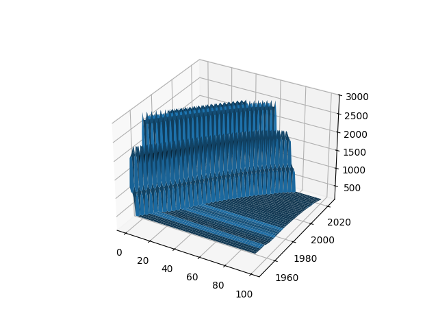

```python
plt.close()
Y = np.arange(1949, 2024)
X = np.arange(0, 100)
X, Y = np.meshgrid(X, Y)
fig = plt.figure()
ax = fig.add_subplot(projection='3d')
ax.plot_surface(X, Y, population.values, antialiased=True)
plt.show()
```

# 计算出生率

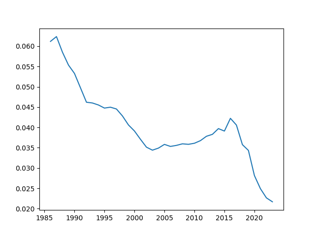

```python
plt.close()
s = population.loc[:, 0]/population.loc[:, 20:40].sum(axis=1)
plt.plot(s[s.index>1985])
plt.show()
```

# 外推出生数据

假设总和生育率维持0.8不变，我们可以推算出接下去35年的人口数据。

```python
for y in range(2023, 2060):
    pop = population.loc[y]
    pop *= (1-life['CL5']-0.0014)
    pop.index += 1
    pop = pop.copy()
    pop.loc[0] = 0.02*population.loc[y, 20:40].sum()
    population.loc[y+1] = pop
```

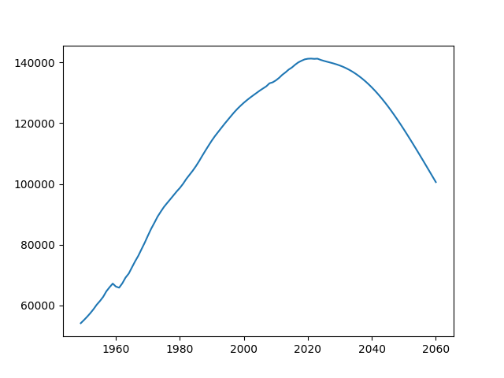

```python
plt.close()
total = population.sum(axis=1)
plt.plot(total)
plt.show()
```

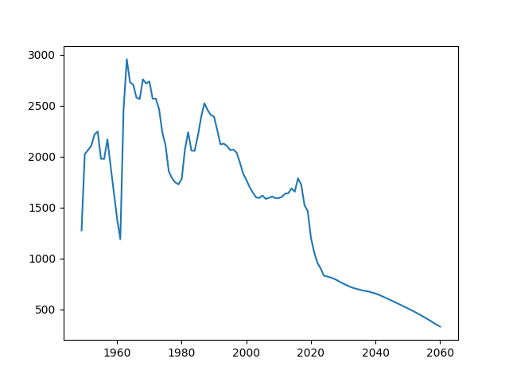

```python
plt.close()
birth = population[0]
plt.plot(birth)
plt.show()
```

# 计算劳动力人口

劳动力采用的是近似计算。20-50岁百分百是劳动力，50-60有一半是劳动力。实际上由于男女性别比例并不是1:1，而且还有女干部退休时间为55岁。因此真实的劳动力数据会比我们算出来的高一些。

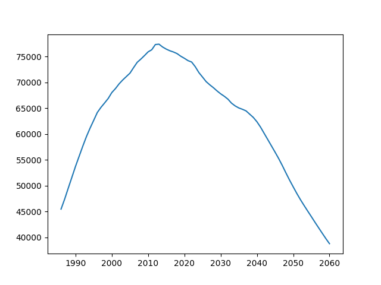

```python
plt.close()
labors = population.loc[:, 20:50].sum(axis=1)+0.5*population.loc[:, 50:60].sum(axis=1)
plt.plot(labors[labors.index>1985])
plt.show()
```

# 计算退休人口

退休人口同样采用近似计算，50-60间一半是退休人口。

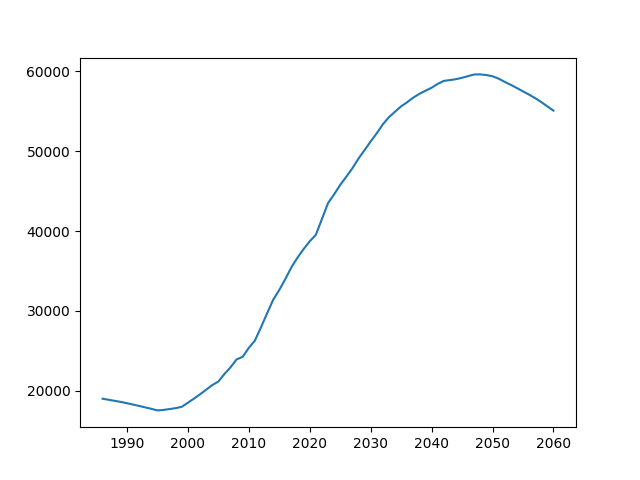

```python
plt.close()
retired = population.loc[:, 60:].sum(axis=1)+0.5*population.loc[:, 50:60].sum(axis=1)
plt.plot(retired[retired.index>1985])
plt.show()
```

# 计算退休供养率

所谓劳动供养率，指劳动人口占总人口的比例。而退休供养率，指退休人口和劳动人口的比例。这个值近似可以理解为“一个劳动人口供养几个退休人口”。

```python
support_ratio = retired/labors
support_ratio[2024]
```

```
np.float64(0.6202988003295761)
```

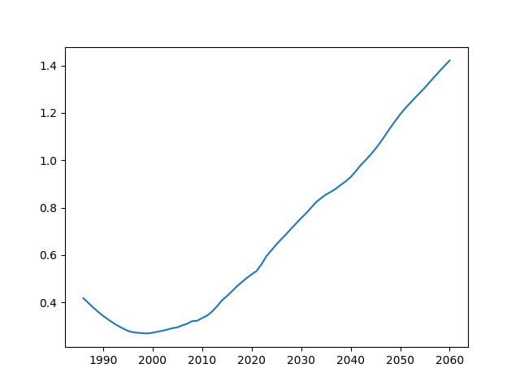

```python
plt.close()
plt.plot(support_ratio[support_ratio.index>1985])
plt.show()
```

# 如果维持退休供养率基本保持在2024年水平，需要延迟到几岁退休

```python
l = []
for f in range(55, 62):
    for m in range(60, 69):
        labors = population.loc[2050, 20:f].sum()+0.5*population.loc[2050, f:m].sum()
        retired = population.loc[2050, m:].sum()+0.5*population.loc[2050, f:m].sum()
        l.append([f, m, labors, retired, retired/labors])

df = pd.DataFrame(l, columns=['F', 'M', 'labors', 'retired', 'support_ratio'])
df = df[df.support_ratio < 0.65]
df = df.set_index(['F', 'M'])
df
```

| F | M | labors | retired | support_ratio |
| --- | --- | --- | --- | --- |
| 60 | 68 | 66975.898663 | 42377.096966 | 0.632722 |
| 61 | 66 | 66254.447990 | 42982.347268 | 0.648747 |
|  | 67 | 67101.644620 | 42122.237771 | 0.627738 |
|  | 68 | 68014.010885 | 41340.210776 | 0.607819 |

# 误差分析

所谓误差分析，即引入不同假设，观察结果的变化。由此可以得出，结论对假设是否敏感，有多敏感。上面我们的假设有数个：

1. 人口老化和死亡分布大致依从生命表。这个假设无法变化，也不能变化。一旦假设不成立，整个计算的前提就不成立了。
2. 生育年龄20-40。
3. 总和生育率维持不变。

# 生育年龄变化影响

使用生育年龄15-49的假定。

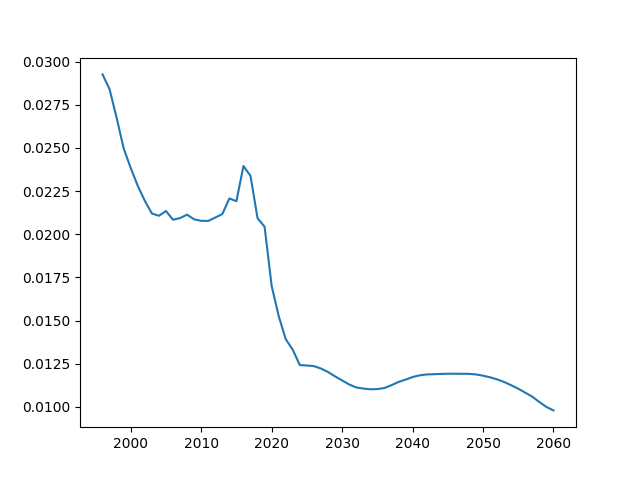

```python
plt.close()
s = population.loc[:, 0]/population.loc[:, 15:50].sum(axis=1)
plt.plot(s[s.index>1995])
plt.show()
```

0.01换算为总和生育率为0.7，比上面的假定还糟糕了。

```python
for y in range(2023, 2060):
    pop = population.loc[y]
    pop *= (1-life['CL5']-0.0014)
    pop.index += 1
    pop = pop.copy()
    pop.loc[0] = 0.01*population.loc[y, 15:50].sum()
    population.loc[y+1] = pop
```

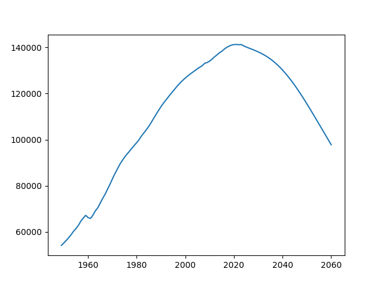

```python
plt.close()
total = population.sum(axis=1)
plt.plot(total)
plt.show()
```

和上面一样，峰值出现在2020前后。

```python
labors = population.loc[:, 20:50].sum(axis=1)+0.5*population.loc[:, 50:60].sum(axis=1)
retired = population.loc[:, 60:].sum(axis=1)+0.5*population.loc[:, 50:60].sum(axis=1)
support_ratio = retired/labors
support_ratio[2024]
```

```
np.float64(0.6202988003295761)
```

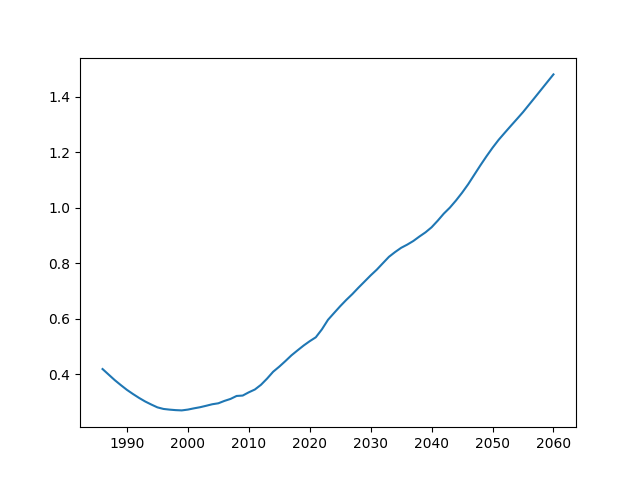

```python
plt.close()
plt.plot(support_ratio[support_ratio.index>1985])
plt.show()
```

结论基本不变。生育年龄假定对结论的影响并不大。

# 总和生育率变化影响

取生育年龄20-40假设。假定总和生育率分别变为0.4和1.6。

```python
for y in range(2023, 2060):
    pop = population.loc[y]
    pop *= (1-life['CL5']-0.0014)
    pop.index += 1
    pop = pop.copy()
    pop.loc[0] = 0.01*population.loc[y, 20:40].sum()
    population.loc[y+1] = pop
```

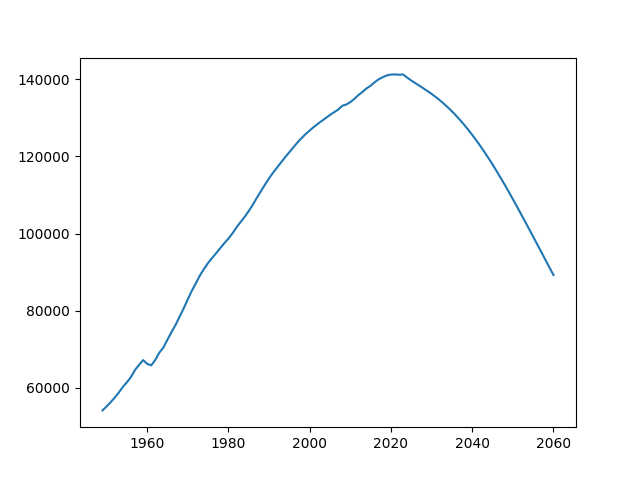

```python
plt.close()
total = population.sum(axis=1)
plt.plot(total)
plt.show()
```

人口峰值依然出现在2020年，没有变化。

```python
labors = population.loc[:, 20:50].sum(axis=1)+0.5*population.loc[:, 50:60].sum(axis=1)
retired = population.loc[:, 60:].sum(axis=1)+0.5*population.loc[:, 50:60].sum(axis=1)
support_ratio = retired/labors
support_ratio[2024]
```

```
np.float64(0.6202988003295761)
```

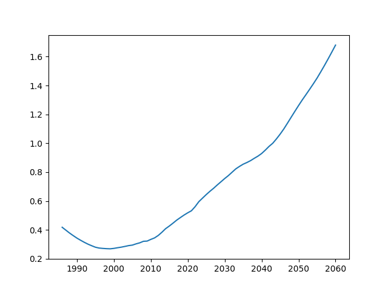

```python
plt.close()
plt.plot(support_ratio[support_ratio.index>1985])
plt.show()
```

可以看到，生育率降低到0.4对供养率有巨大的影响。结果是供养率进一步升高，更少的年轻人需要供养更多老人。

```python
l = []
for f in range(55, 63):
    for m in range(60, 70):
        labors = population.loc[2050, 20:f].sum()+0.5*population.loc[2050, f:m].sum()
        retired = population.loc[2050, m:].sum()+0.5*population.loc[2050, f:m].sum()
        l.append([f, m, labors, retired, retired/labors])

df = pd.DataFrame(l, columns=['F', 'M', 'labors', 'retired', 'support_ratio'])
df = df[df.support_ratio < 0.65]
df = df.set_index(['F', 'M'])
df
```

| F | M | labors | retired | support_ratio |
| --- | --- | --- | --- | --- |
| 60 | 69 | 65122.438257 | 41387.023523 | 0.635526 |
| 61 | 68 | 65325.891392 | 41340.210776 | 0.632830 |
|  | 69 | 66160.550479 | 40350.137333 | 0.609882 |
| 62 | 66 | 64633.303252 | 41944.848062 | 0.648966 |
|  | 67 | 65480.499882 | 41084.738565 | 0.627435 |
|  | 68 | 66392.866147 | 40302.711570 | 0.607034 |
|  | 69 | 67227.525234 | 39312.638126 | 0.584770 |

从推算也能看出，低生育率下男女退休年龄更大。平均比总和生育率0.8的假设推迟1-2岁。

# 总和生育率上升

```python
for y in range(2023, 2060):
    pop = population.loc[y]
    pop *= (1-life['CL5']-0.0014)
    pop.index += 1
    pop = pop.copy()
    pop.loc[0] = 0.04*population.loc[y, 20:40].sum()
    population.loc[y+1] = pop
```

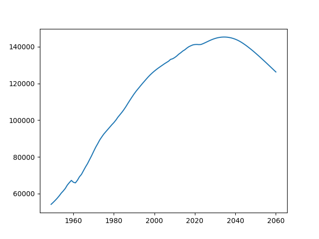

```python
plt.close()
total = population.sum(axis=1)
plt.plot(total)
plt.show()
```

可以看到，人口拐点显著延后。

```python
labors = population.loc[:, 20:50].sum(axis=1)+0.5*population.loc[:, 50:60].sum(axis=1)
retired = population.loc[:, 60:].sum(axis=1)+0.5*population.loc[:, 50:60].sum(axis=1)
support_ratio = retired/labors
support_ratio[2024]
```

```
np.float64(0.6202988003295761)
```

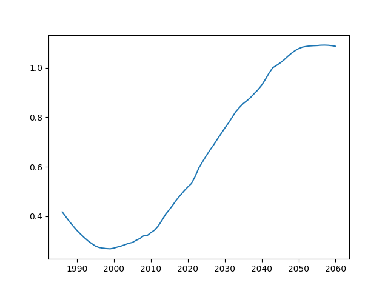

```python
plt.close()
plt.plot(support_ratio[support_ratio.index>1985])
plt.show()
```

可以看到，供养率数据恶化比之前显著好转。且2050左右供养率已经不再进一步恶化。

```python
l = []
for f in range(55, 62):
    for m in range(60, 68):
        labors = population.loc[2050, 20:f].sum()+0.5*population.loc[2050, f:m].sum()
        retired = population.loc[2050, m:].sum()+0.5*population.loc[2050, f:m].sum()
        l.append([f, m, labors, retired, retired/labors])

df = pd.DataFrame(l, columns=['F', 'M', 'labors', 'retired', 'support_ratio'])
df = df[df.support_ratio < 0.65]
df = df.set_index(['F', 'M'])
df
```

| F | M | labors | retired | support_ratio |
| --- | --- | --- | --- | --- |
| 59 | 66 | 69503.647768 | 45004.078853 | 0.647507 |
|  | 67 | 70350.844398 | 44143.969356 | 0.627483 |
| 60 | 65 | 69738.921690 | 45010.490092 | 0.645414 |
|  | 66 | 70592.574753 | 44019.233458 | 0.623567 |
|  | 67 | 71439.771383 | 43159.123961 | 0.604133 |
| 61 | 64 | 69854.579064 | 45064.291273 | 0.645116 |
|  | 65 | 70777.033912 | 43973.603901 | 0.621298 |
|  | 66 | 71630.686976 | 42982.347268 | 0.600055 |
|  | 67 | 72477.883606 | 42122.237771 | 0.581174 |

退休年龄也会大幅提前，平均提前1-2岁。